# Coursera’s Practical Machine Learning Project - Quantified Self Movement Prediction Report

Ferran Briansó

February 14th 2016

## Introduction

Using devices such as Jawbone Up, Nike FuelBand, and Fitbit it is now possible to collect a large amount of data about personal activity relatively inexpensively. These type of devices are part of the quantified self movement – a group of enthusiasts who take measurements about themselves regularly to improve their health, to find patterns in their behavior, or because they are tech geeks. One thing that people regularly do is quantify how much of a particular activity they do, but they rarely quantify how well they do it.

In this project, our goal is to use data from accelerometers on the belt, forearm, arm, and dumbell of 6 participants to predict the manner in which they did some barbell lifts (correctly or incorrectly, as recorded in the “classe” field of the training set).

More information is available from the website here: http://groupware.les.inf.puc-rio.br/har (see the section on the Weight Lifting Exercise Dataset).

## Load R packages

```r
library(caret)
```

```r
library(corrplot)
library(randomForest)
library(rattle)
library(rpart)
library(rpart.plot)
```

## Data pre-processing

### Download files from the web

Get data files downlading them from the web

```r
train.url <- "https://d396qusza40orc.cloudfront.net/predmachlearn/pml-training.csv"
test.url <- "https://d396qusza40orc.cloudfront.net/predmachlearn/pml-testing.csv"
train.fname <- "./data/pml-training.csv"
test.fname  <- "./data/pml-testing.csv"
if (!file.exists("./data")) {
  dir.create("./data")
}
if (!file.exists(train.fname)) {
  download.file(train.url, destfile=train.fname, method="curl")
}
if (!file.exists(test.fname)) {
  download.file(test.url, destfile=test.fname, method="curl")
}
```

### Load raw data

After downloading the csv files from the web, data can be loaded into the corresponding data frames.

```r
train.raw <- read.csv(train.fname)
test.raw <- read.csv(test.fname)
colnames(train.raw)
```

```
##   [1] "X"                        "user_name"
##   [3] "raw_timestamp_part_1"     "raw_timestamp_part_2"
##   [5] "cvtd_timestamp"           "new_window"
##   [7] "num_window"               "roll_belt"
##   [9] "pitch_belt"               "yaw_belt"
##  [11] "total_accel_belt"         "kurtosis_roll_belt"
##  [13] "kurtosis_picth_belt"      "kurtosis_yaw_belt"
##  [15] "skewness_roll_belt"       "skewness_roll_belt.1"
##  [17] "skewness_yaw_belt"        "max_roll_belt"
##  [19] "max_picth_belt"           "max_yaw_belt"
##  [21] "min_roll_belt"            "min_pitch_belt"
##  [23] "min_yaw_belt"             "amplitude_roll_belt"
##  [25] "amplitude_pitch_belt"     "amplitude_yaw_belt"
##  [27] "var_total_accel_belt"     "avg_roll_belt"
##  [29] "stddev_roll_belt"         "var_roll_belt"
```

[output cut: 65 more lines]

The training data set has 19622 observations and 160 variables, while the testing data set contains 20 cases and the same 160 variables. The “classe” variable in the training set is the outcome that we pretend to predict with this analysis.

### Data cleaning

```r
train.raw <- train.raw[ , colSums(is.na(train.raw)) == 0]
test.raw <- test.raw[ , colSums(is.na(test.raw)) == 0]
outcome <- train.raw$classe
train.cols2rm <- grepl("^X|timestamp|window", names(train.raw))
train.raw <- train.raw[ , !train.cols2rm]
train.tidy <- train.raw[ , sapply(train.raw, is.numeric)]
train.tidy$classe <- outcome
test.cols2rm <- grepl("^X|timestamp|window", names(test.raw))
test.raw <- test.raw[ , !test.cols2rm]
test.tidy <- test.raw[ , sapply(test.raw, is.numeric)]
```

After that, the tidy training data set contains 19622 records and 53 variables, while the tidy testing data set contains 20 observations and 53 variables.

### Data splitting

The tidy training set can be separated into a real training set (66%, as the usual 2/3) and a internal validation data set (34%), that will be used afterwards for cross-validation.

```r
set.seed(1977) # to allow reproducibility
in.train <- createDataPartition(train.tidy$classe, p = 0.66, list = FALSE)
train.data <- train.tidy[in.train, ]
test.data <- train.tidy[-in.train, ]
```

## Data Modeling

A predictive model for good or bad activity recognition is fitted here using **Random Forest** algorithm. We applied this method because it is quite robust to correlation effects between variables and outlier presence. It can be affected somehow by the seed stablished for the algorithm, but performs automatic selection of the most relevant variables, and its putative overfitting has been controled by applying a **5-fold cross validation**.

```r
cv.control <- trainControl(method="cv", 5)
rf.model <- train(classe ~ ., data = train.data, method = "rf",
                  trControl = cv.control, ntree = 250)
rf.model
```

```
## Random Forest
##
## 12953 samples
##    52 predictors
##     5 classes: 'A', 'B', 'C', 'D', 'E'
##
## No pre-processing
## Resampling: Cross-Validated (5 fold)
## Summary of sample sizes: 10364, 10361, 10361, 10363, 10363
## Resampling results across tuning parameters:
##
##   mtry  Accuracy   Kappa      Accuracy SD   Kappa SD
##    2    0.9897317  0.9870103  0.0011164237  0.0014119888
##   27    0.9901179  0.9874989  0.0006502464  0.0008230367
##   52    0.9854091  0.9815422  0.0029310439  0.0037094454
##
## Accuracy was used to select the optimal model using  the largest value.
## The final value used for the model was mtry = 27.
```

So, the performance of the model on the validation data set (that third coming from training set) can be measured as follows

```r
rf.predict <- predict(rf.model, test.data)
conf.matrix <- confusionMatrix(test.data$classe, rf.predict)
conf.matrix
```

[output not shown]

```r
res.accur <- postResample(rf.predict, test.data$classe)
res.accur
```

```
##  Accuracy     Kappa
## 0.9938828 0.9922616
```

```r
res.oose <- 1 - as.numeric(conf.matrix$overall[1])
res.oose
```

```
## [1] 0.006117247
```

## Predicting for Test Data Set

Now, we apply the model to the original testing data set downloaded from the data source. We remove the `problem_id` column first.

```r
prediction <- predict(rf.model, test.tidy[, -length(names(test.tidy))])
prediction
```

```
##  [1] B A B A A E D B A A B C B A E E A B B B
## Levels: A B C D E
```

## Additional Figures

Figure 1. Correlation Matrix Plot

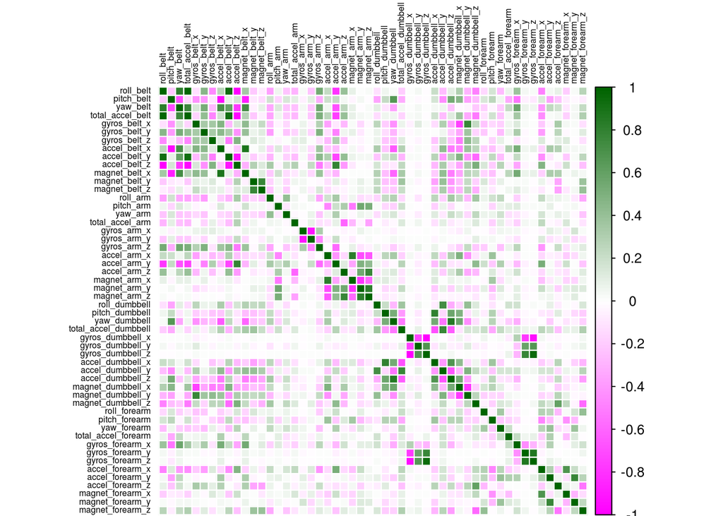

```r
corrPlot <- cor(train.data[ , -length(names(train.data))])
corrplot(corrPlot, method="color", tl.cex = .5, tl.col = "black",
         col=colorRampPalette(c("magenta", "white", "darkgreen"))(128))
```

Figure 2. Decision Tree Diagram

```r
treeModel <- rpart(classe ~ ., data=train.data, method="class")
pdf(file="treePlot.pdf") # fancy plot saved as pdf
  fancyRpartPlot(treeModel, sub="Classification Tree with rattle package")
dev.off()
```

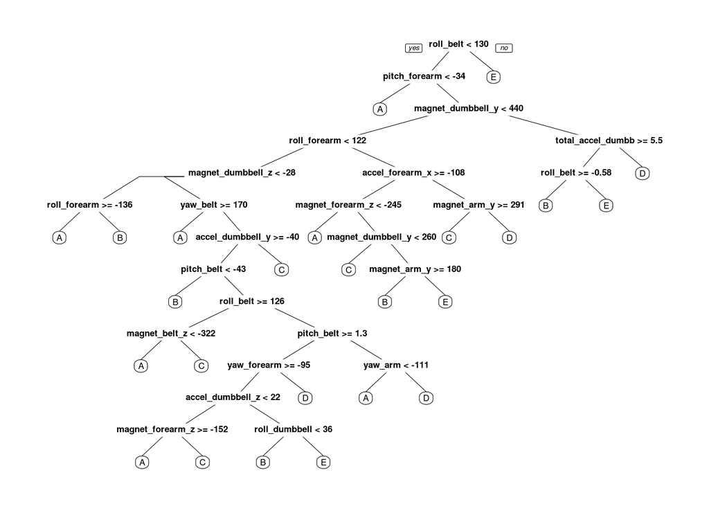

```r
prp(treeModel) # simple plot that fits in the html file
```

Figure 3. Prediction Performance

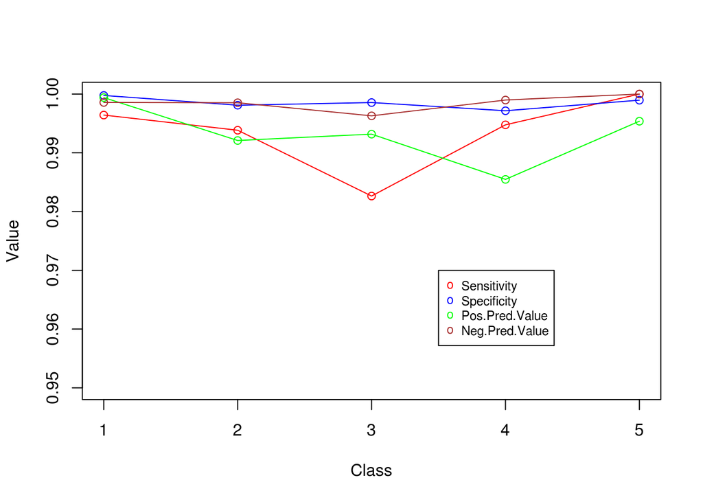

```r
plot(conf.matrix$byClass[ ,1], col = "red", ylim = c(0.95, 1), ylab = "Value", xlab = "Class")
lines(conf.matrix$byClass[ ,1], col = "red")
points(conf.matrix$byClass[ ,2], col = "blue")
lines(conf.matrix$byClass[ ,2], col = "blue")
points(conf.matrix$byClass[ ,3], col = "green")
lines(conf.matrix$byClass[ ,3], col = "green")
points(conf.matrix$byClass[ ,4], col = "brown")
lines(conf.matrix$byClass[ ,4], col = "brown")
legend(3.5, 0.97, c("Sensitivity","Specificity","Pos.Pred.Value","Neg.Pred.Value"),
       cex = .75, pch = "oooo", col = c("red", "blue", "green", "brown"))
```